# Лабораторная работа №4

Графика в LaTeX

Мунтаха Сидратул

Российский университет дружбы народов, Москва, Россия

13 декабря 2025

# Цель работы

## Основная цель

Изучение способов включения, оформления и размещения графических изображений  
в документах, создаваемых с использованием системы вёрстки **LaTeX**.

# Подключение графики

## Компиляция исходных файлов

В рабочем каталоге были открыты и скомпилированы файлы:

- `graphics1.tex`
- `graphics2.tex`

Компиляция выполнена с помощью команды `pdflatex`.

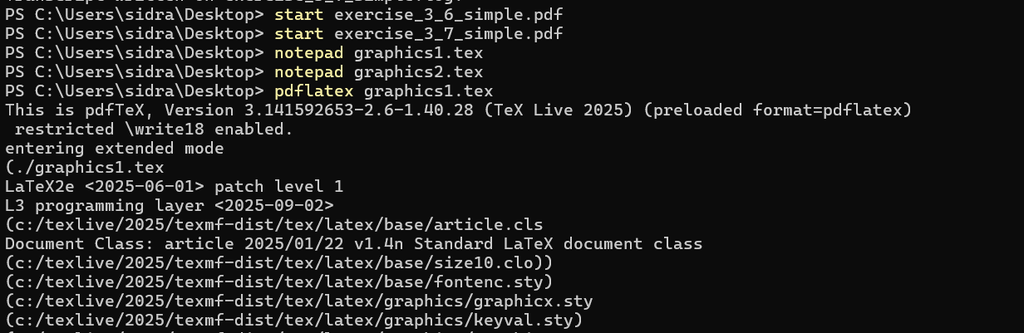

Компиляция файла graphics1.tex

## Предупреждения при компиляции

При первой компиляции файла `graphics2.tex` были получены предупреждения о неразрешённых перекрёстных ссылках, что является ожидаемым результатом.

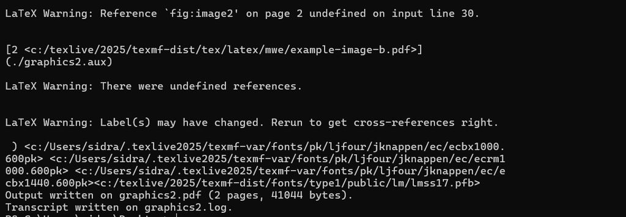

Предупреждение о ссылках

# Управление размером изображений

## Простое включение изображения

В документе показано центрированное изображение, включённое с помощью команды `\includegraphics`.

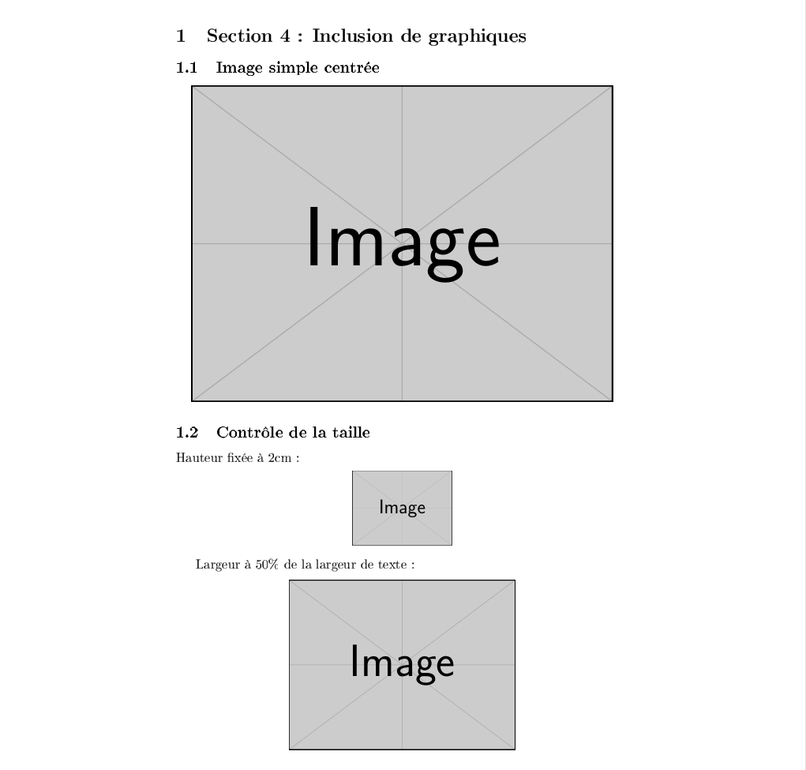

Простое центрированное изображение

## Изменение размеров

Продемонстрированы различные способы задания размеров:

- фиксированная высота (2 см);
- ширина относительно `\textwidth`;
- масштабирование с помощью `scale`.

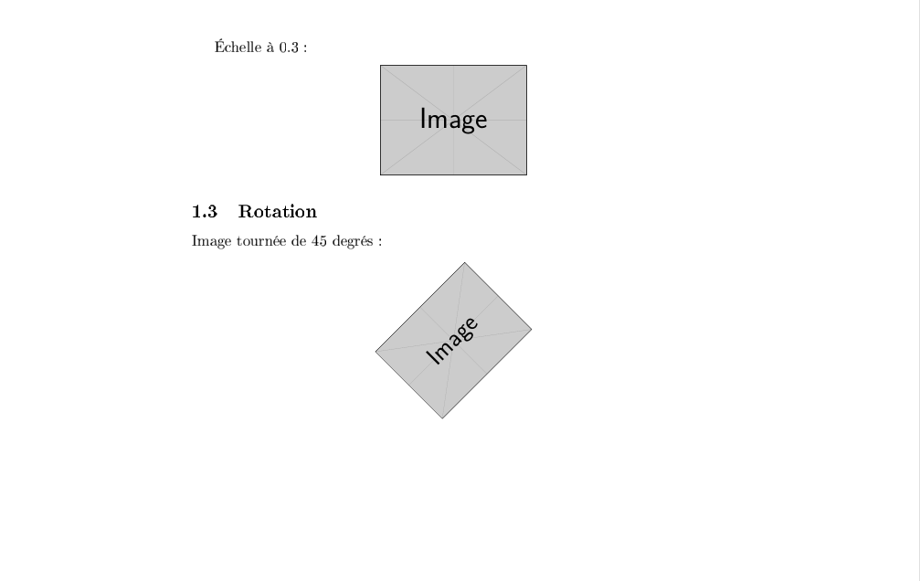

Контроль размеров изображения

# Поворот изображений

## Использование параметра `angle`

[figure not shown]

# Плавающие рисунки

## Использование окружения `figure`

В файле `graphics2.tex` изображения размещены как плавающие объекты с подписями и нумерацией.

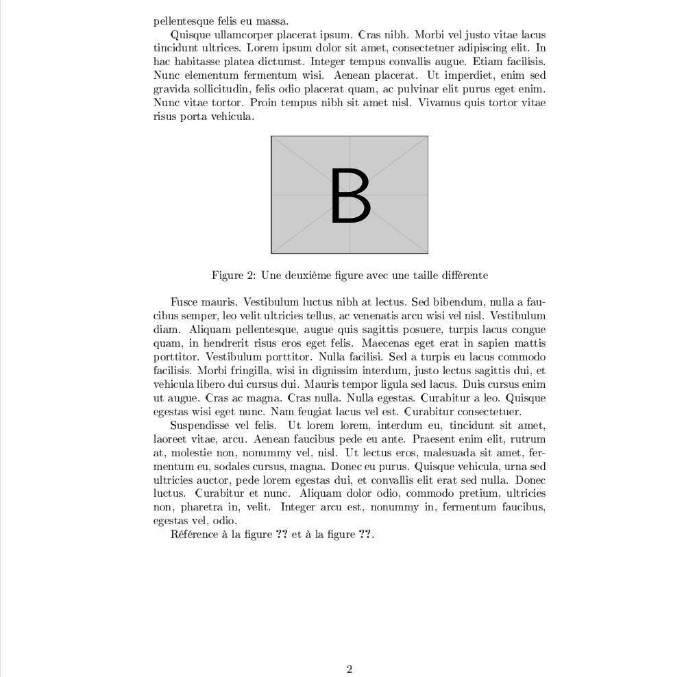

## Автоматическое размещение

LaTeX автоматически размещает рисунки наиболее подходящим образом на странице.

[figure not shown]

## Перекрёстные ссылки

При первом запуске номера рисунков ещё не определены, что приводит к отображению `??` в тексте.

[figure not shown]

# Работа с файлами и каталогами

## Проверка сгенерированных PDF

После компиляции выполнена проверка наличия PDF-файлов в рабочем каталоге.

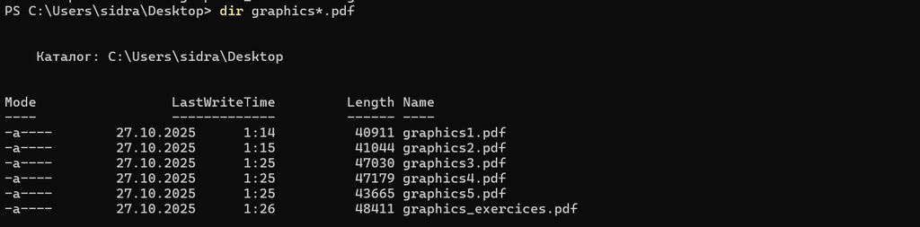

Список PDF-файлов

## Организация изображений

Показано хранение изображений в подкаталогах и настройка путей с помощью команды `\graphicspath`.

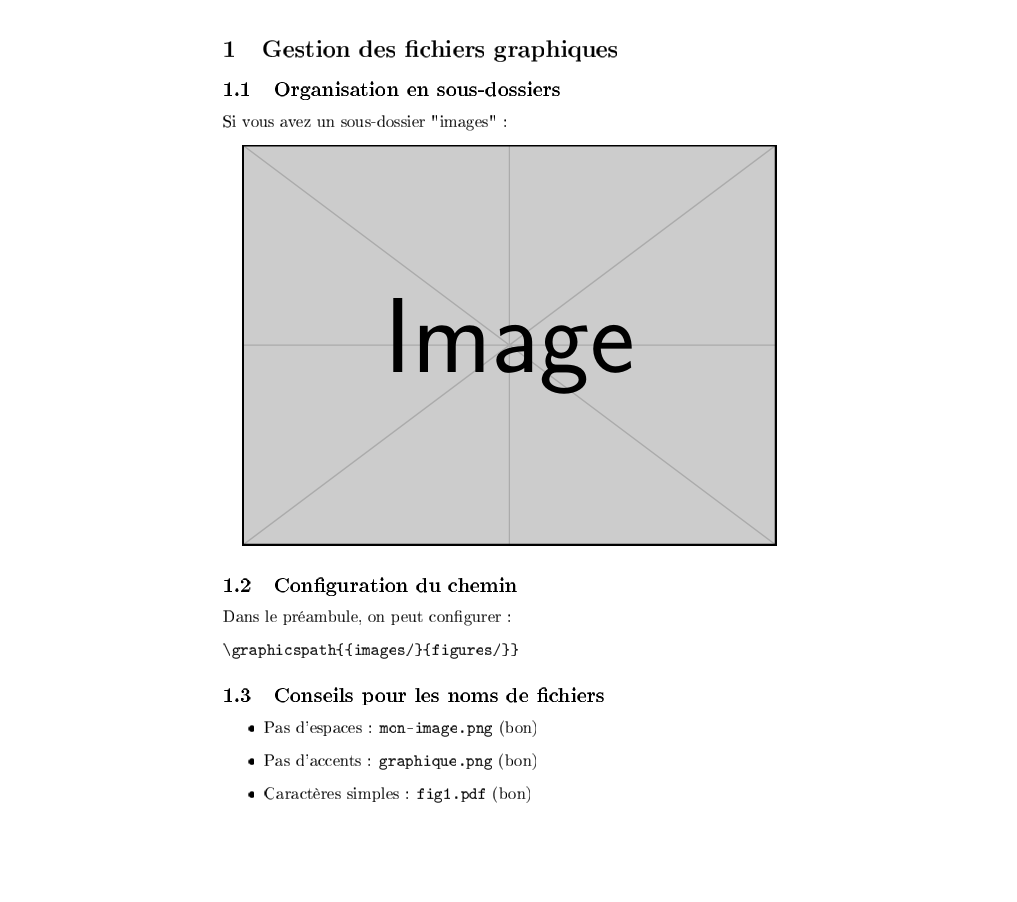

Работа с подкаталогами

# Продвинутое размещение

## Размещение с параметром `H`

Использован параметр `H`, обеспечивающий строгое размещение рисунка в указанном месте.

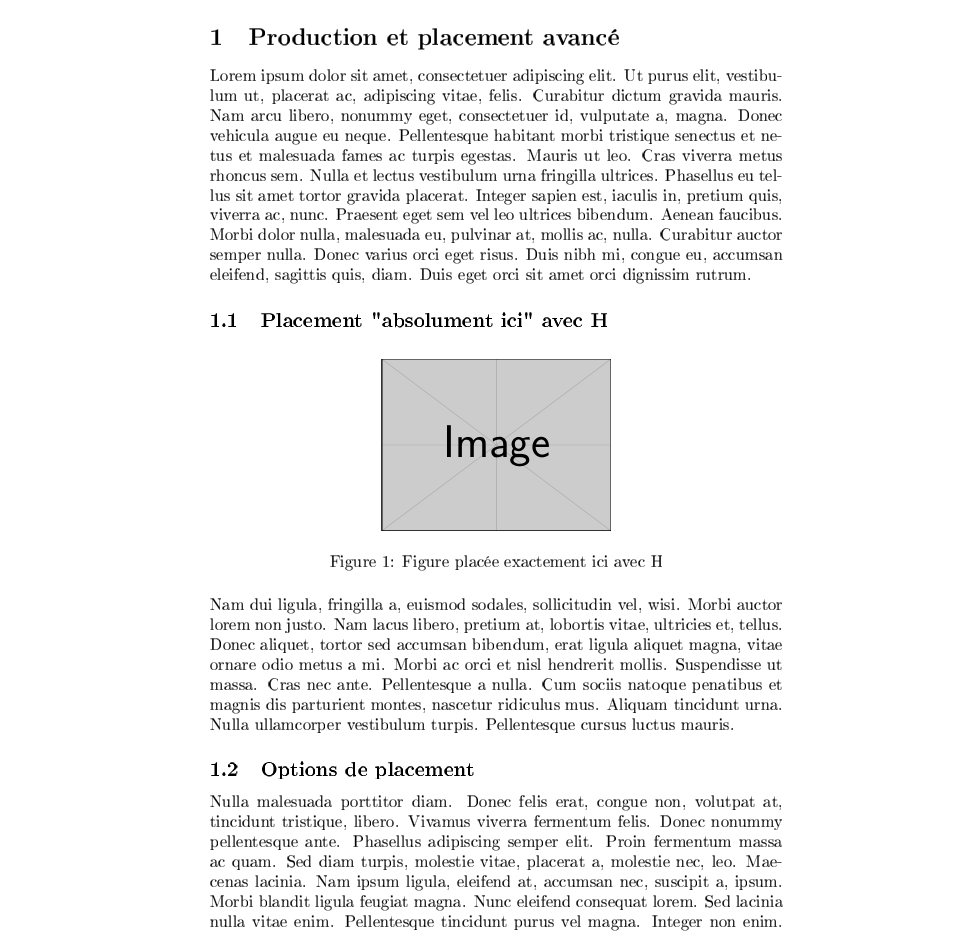

Размещение с H

## Параметры `h`, `t`, `b`, `p`

Продемонстрированы стандартные параметры размещения, позволяющие LaTeX автоматически управлять положением рисунков.

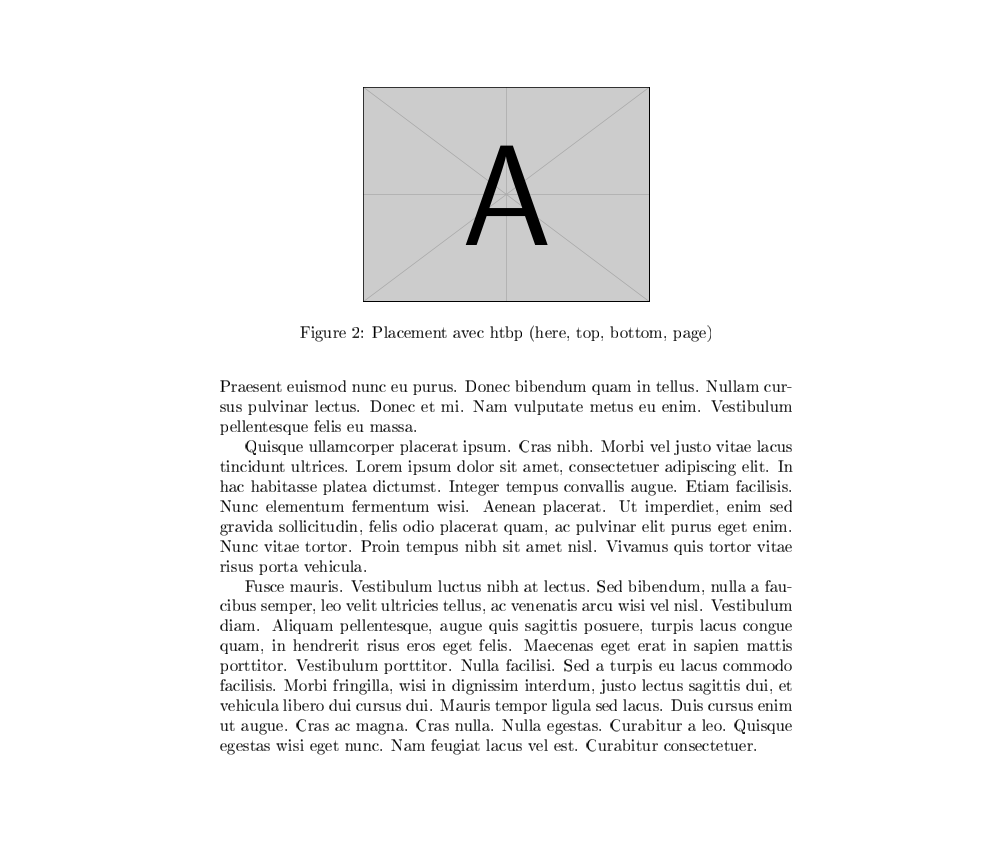

Размещение htbp

# Перекрёстные ссылки и гиперссылки

## Ссылки на рисунки

После повторной компиляции перекрёстные ссылки корректно отображают номера рисунков.

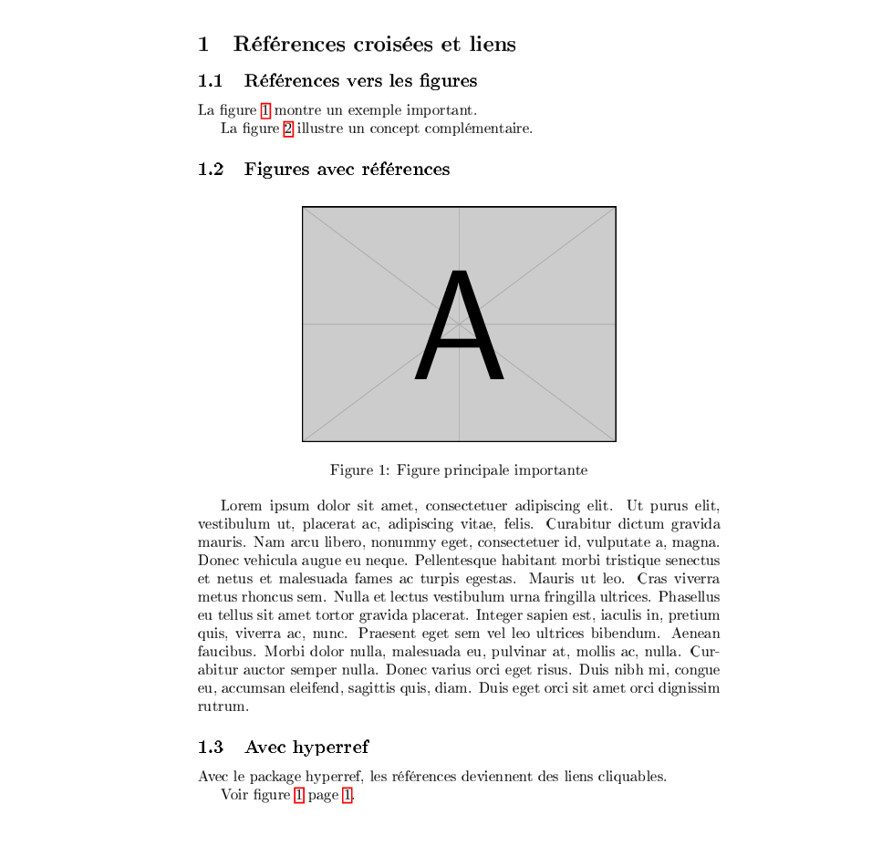

Корректные ссылки

## Использование `hyperref`

Подключение пакета `hyperref` делает ссылки кликабельными в PDF-документе.

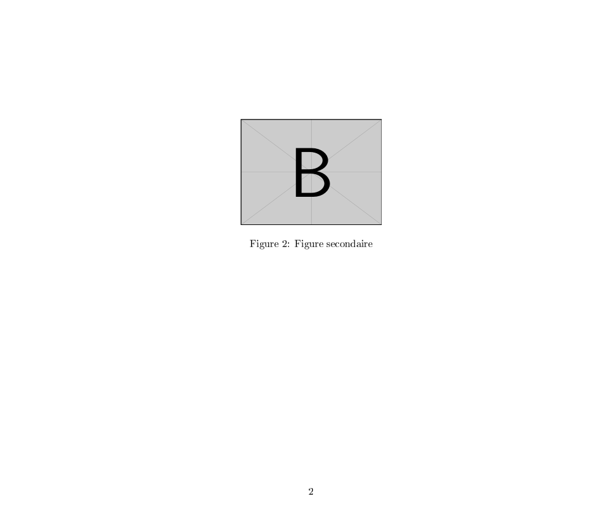

Гиперссылки

# Упражнения

## Изменение размеров

Выполнены упражнения по изменению ширины изображений (25% и 75% от ширины текста).

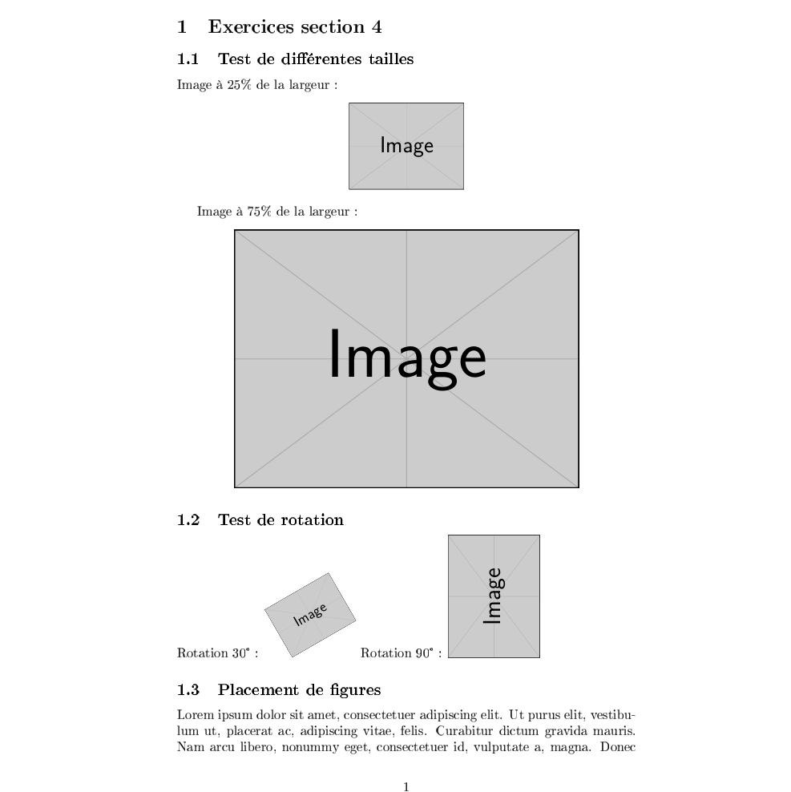

Изменение размеров

## Поворот изображений

[figure not shown]

## Размещение нескольких фигур

[figure not shown]

# Итоги работы

## Вывод

В ходе выполнения лабораторной работы были освоены:

- подключение графических файлов в LaTeX;
- управление размерами и ориентацией изображений;
- использование плавающих объектов (`figure`);
- организация файлов изображений;
- создание перекрёстных и кликабельных ссылок.

LaTeX предоставляет гибкие и мощные средства для работы с графикой в научных и технических документах.